# Домашнее задание 2

## Выполнила Стогова Анастасия, БЭК213

```python
import numpy as np
import matplotlib.pyplot as plt
from scipy import stats
import pandas as pd
from tqdm import tqdm
from math import sqrt
from scipy.stats import expon, norm
```

## Задача 1

### a)

Пусть $X$ - случайная величина, показывающая, на каком заказе к туристу в первый раз приедет таксист, который уже раньше приезжал к нему, тогда:

$ P(X = 2) = \frac{1}{n}\\ P(X = 3) = \frac{n-1}{n}\cdot\frac{2}{n}\\ $

$...$

$ P(X = 10) = \frac{n-1}{n}\cdot\frac{n-2}{n}\cdot\ldots\cdot\frac{n-8}{n}\cdot\frac{9}{n} = \frac{9(n-1)\ldots(n-8)}{n^9} $ - искомая функция правдоподобия

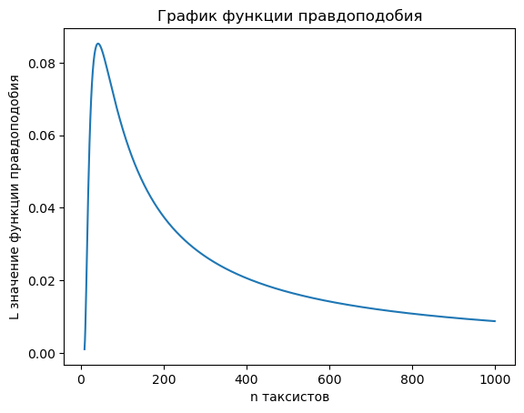

```python
def P(x):
    P = 9 / x
    for i in range(1, 9):
        P = P*(x - i)/ x
    return P

ns = np.arange(9, 1000)

plt.plot(ns, P(ns))
plt.xlabel('n таксистов')
plt.ylabel('L значение функции правдоподобия')
plt.title('График функции правдоподобия')
```

Найдем оценку методом максимального правдоподобия:

$$ \ln L = \ln 9 + \sum_{i=1}^8 \ln (n-i) -9\ln n \\ \frac{\partial\ln L}{\partial n} = \sum_{i=1}^{8} \frac{1}{\hat n_{ML} - i} -\frac{9}{\hat n_{ML}}= 0\\ \frac{\partial^2\ln L}{\partial n^2} = - \sum_{i=1}^{8} \frac{1}{(n - i)^2} + \frac{9}{n^2} < 0\\ $$

С помощью WolframAlpha решаем уравнение и получаем, что $\hat n_{ML} = 42$.

### б)

```python
def expectation(n):
    expect = 0
    prob = 1
    for i in range(2, n + 2):
        expect += i * (i - 1) * prob / n
        prob = prob * (n - (i - 1)) / n
    return expect
ns = np.arange(1,1000)
expectations = np.array([expectation(n) for n in ns])
```

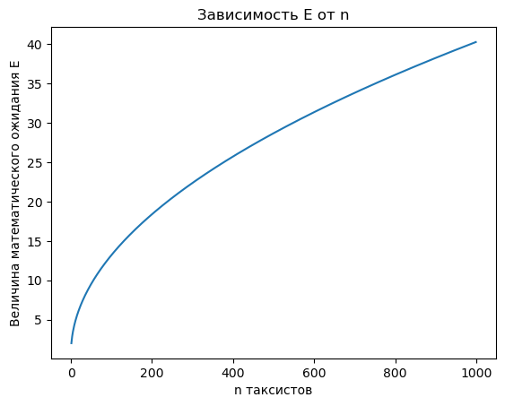

```python
plt.plot(ns, expectations);
plt.xlabel('n таксистов')
plt.ylabel('Величина математического ожидания E')
plt.title('Зависимость E от n');
```

Найдем оценку n методом моментов:

```python
print('n =', ns[np.argmin(abs(np.array(expectations)-10))])
```

```
n = 55
```

### в)

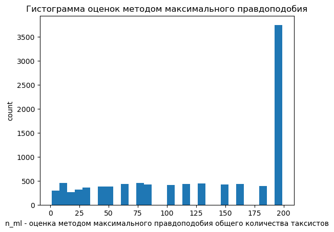

```python
np.random.seed(42)

ns = range(1, 201)  # Диапазон общего количества таксистов

ts = []
for i in range(10000):  # Генерируем 10000 вызовов такси до первого повторяющегося
    t = []
    repeated = False
    while not repeated:
        taxi = np.random.choice(ns, 1)
        if taxi not in t:
            t.append(taxi)
        else:
            ts.append(len(t) + 1)  # Сохраняем номер повторного
            repeated = True

def p(x, n):  # Функция, которая выводит вероятность повторного таксиста на x-ый раз
    return ((x - 1) * math.factorial(n - 1) / math.factorial(n - x + 1)) / n ** (x - 1)

ps = []
ml = []
for x in ts:
    prob = [p(x, n) for n in range(x - 1, 200)]
    ps.append(max(prob))  # Находим 10000 вероятностей
    ml.append([i for i in range(x - 1, 200)][prob.index(max(prob))])

plt.hist(ml, bins=30)
plt.xlabel('n_ml - оценка методом максимального правдоподобия общего количества таксистов')
plt.ylabel('count')
plt.title('Гистограмма оценок методом максимального правдоподобия')
plt.show()
```

## Задача 2

### а)

```python
import numpy as np
import itertools
import matplotlib.pyplot as plt

def calculate_likelihood(n, u, d):
    likelihood = 1
    for i in range(1, u):
        likelihood *= (n - i) / n

    combinations = itertools.combinations_with_replacement(range(1, u + 1), r=d - u)
    sum_of_products = np.sum([np.prod(t) for t in list(combinations)])
    likelihood *= sum_of_products / (n ** (d - u))

    return likelihood

def find_maximum_likelihood_estimate(u, d):
    ns = range(u, 101)
    likelihoods = [calculate_likelihood(n, u, d) for n in ns]
    best_n = ns[np.argmax(likelihoods)]

    return best_n

def calculate_expected_value(n, d):
    expected_value = 0
    for u in range(d + 1):
        expected_value += calculate_likelihood(n, u, d) * u

    return expected_value

def find_method_of_moments_estimate(x):
    ns = range(1, 101)
    expected_values = [calculate_expected_value(n, 10) for n in ns]
    best_n = ns[np.argmin(np.abs(np.array(expected_values) - x))]

    return best_n
```

```
Оценка числа n методом максимального правдоподобия: 8
```

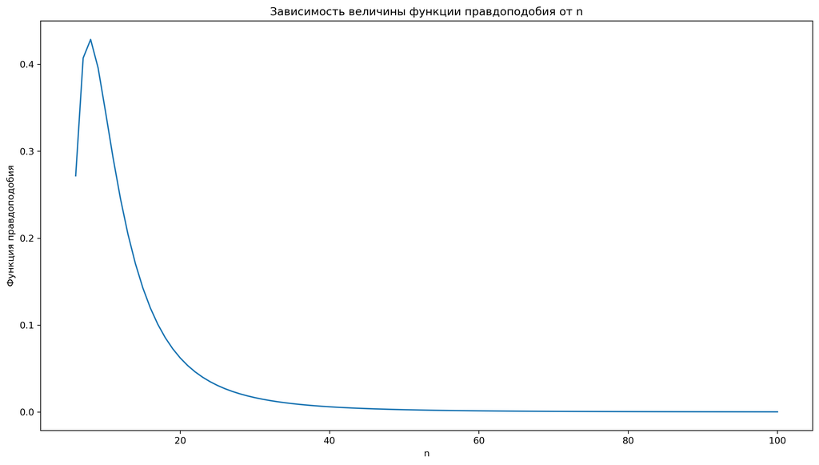

```python
ns = range(6, 101)
likelihoods = [calculate_likelihood(n, 6, 10) for n in ns]

plt.figure(figsize=(15, 8), dpi=300)
plt.plot(ns, likelihoods)
plt.title('Зависимость величины функции правдоподобия от n')
plt.xlabel('n')
plt.ylabel('Функция правдоподобия')

ml_estimate = find_maximum_likelihood_estimate(6, 10)
print('Оценка числа n методом максимального правдоподобия:', ml_estimate)
```

### б)

```
Оценка числа n методом моментов: 8
```

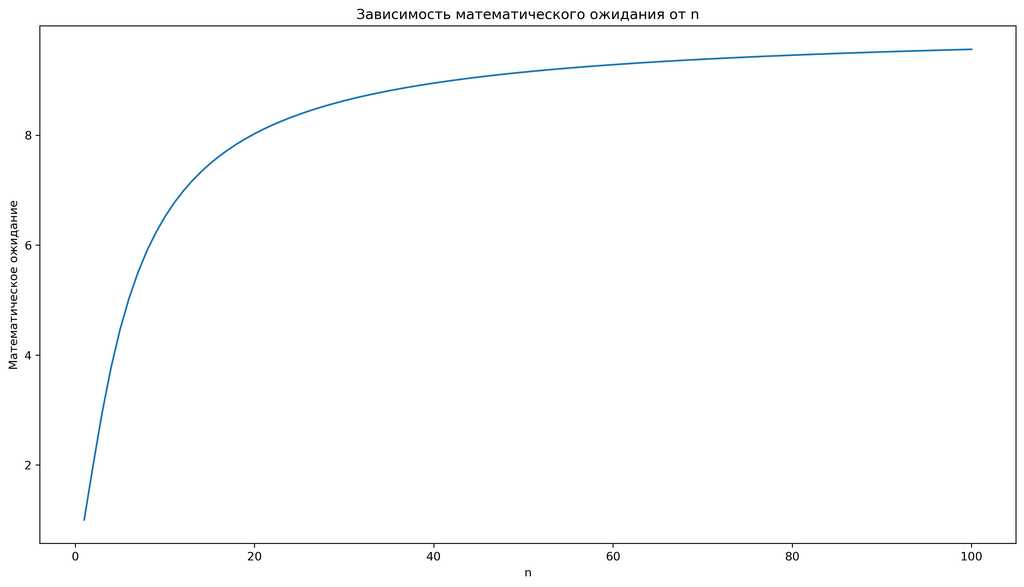

```python
ns = range(1, 101)
expected_values = [calculate_expected_value(n, 10) for n in ns]

plt.figure(figsize=(15, 8), dpi=300)
plt.plot(ns, expected_values)
plt.title('Зависимость математического ожидания от n')
plt.xlabel('n')
plt.ylabel('Математическое ожидание')

mm_estimate = find_method_of_moments_estimate(6)
print('Оценка числа n методом моментов:', mm_estimate)
```

### в)

```python
from sklearn.metrics import mean_absolute_error, mean_squared_error

def generate_samples(n, d, num_samples):
    samples = []
    np.random.seed(3)
    taxi = np.random.choice(range(1, n + 1), size=(num_samples, d))
    for i in taxi:
        samples.append(len(set(i)))

    return samples

def calculate_expected_value(n, d):
    expected_value = 0
    for u in range(d + 1):
        expected_value += L(n, u, d) * u
    return expected_value

def find_ML(u, d):
    ns = range(u, 101)
    Ls = []
    for n in ns:
        Ls.append(L(n, u, d))
    best_n = ns[np.argmax(Ls)]
    return best_n

def find_MM(x):
    ns = range(1, 101)
    return ns[np.argmin(abs(np.array(expected_values) - x))]

def L(n, u, d):
    L = 1
    for i in range(1, u):
        L *= (n - i) / n
    combinations = itertools.combinations_with_replacement(range(1, u + 1), r=d - u)
    summa = np.sum([proizved(t) for t in list(combinations)])
    L *= summa / (n ** (d - u))
    return L

def proizved(tuple):
    proizv = 1
    for i in tuple:
        proizv *= i
    return proizv

# Генерация выборки
true_n = 20
num_samples = 10000
samples = generate_samples(true_n, 10, num_samples)

# Расчет матожидания
expected_values = [calculate_expected_value(n, 10) for n in range(1, 101)]
```

```
Смещение = 14.0178
Дисперсия = 506.9889109999999
Среднеквадратичная ошибка = 570.7172
```

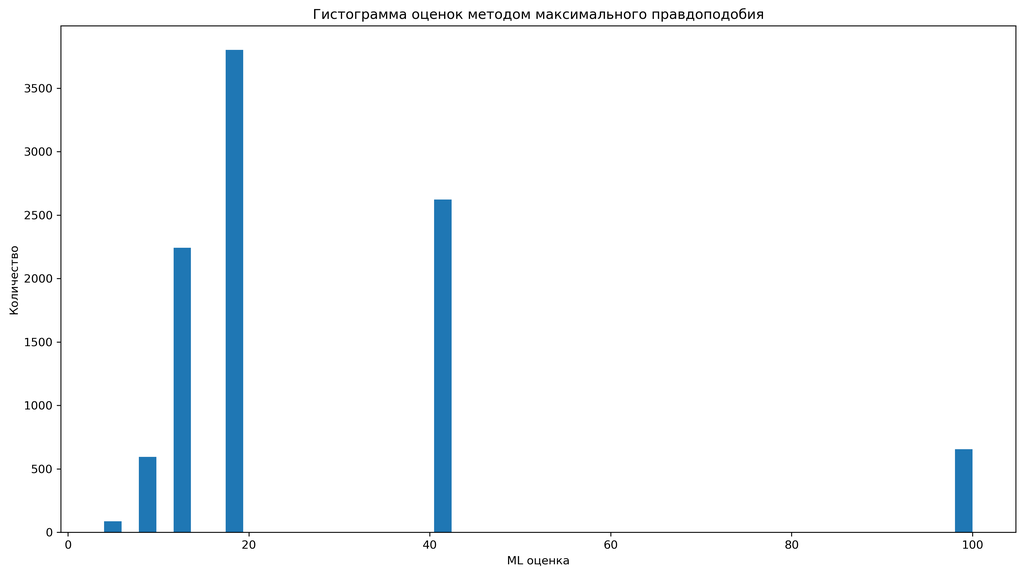

```python
# Метод максимального правдоподобия
find_ML_vec = np.vectorize(find_ML, excluded=set([1]))
ML_estimates = find_ML_vec(samples, 10)

plt.figure(figsize=(15, 8), dpi=300)
plt.hist(ML_estimates, bins=50)
plt.title('Гистограмма оценок методом максимального правдоподобия')
plt.xlabel('ML oценка')
plt.ylabel('Количество')

bias = mean_absolute_error([true_n] * num_samples, ML_estimates)
variance = np.var(ML_estimates)
mse = mean_squared_error([true_n] * num_samples, ML_estimates)

print('Смещение =', bias)
print('Дисперсия =', variance)
print('Среднеквадратичная ошибка =', mse)
```

```
Смещение = 13.6294
Дисперсия = 500.01606204
Среднеквадратичная ошибка = 570.0964
```

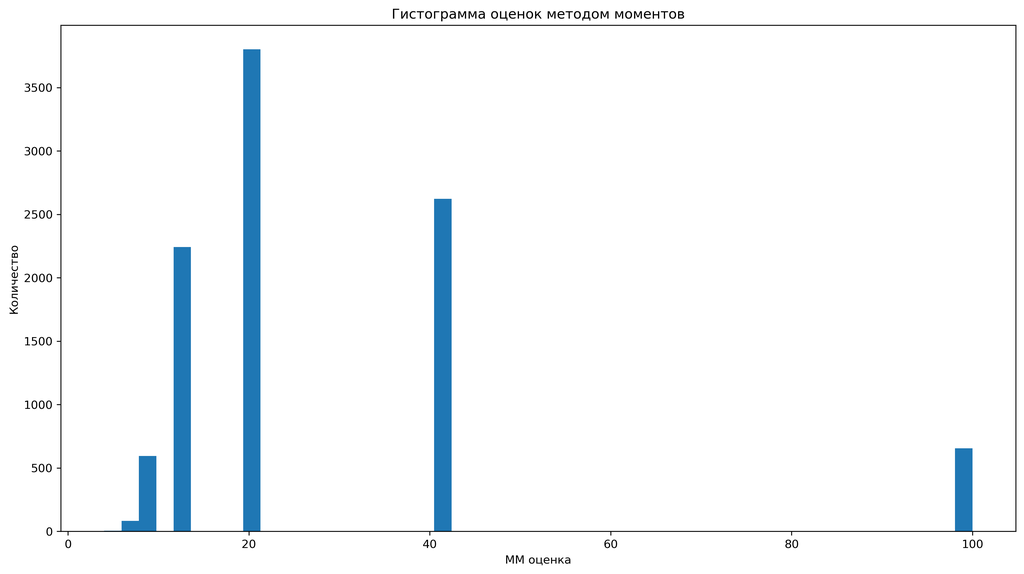

```python
# Метод моментов
find_MM_vec = np.vectorize(find_MM)
MM_estimates = find_MM_vec(samples)

plt.figure(figsize=(15, 8), dpi=300)
plt.hist(MM_estimates, bins=50)
plt.title('Гистограмма оценок методом моментов')
plt.xlabel('MM oценка')
plt.ylabel('Количество')

bias = mean_absolute_error([true_n] * num_samples, MM_estimates)
variance = np.var(MM_estimates)
mse = mean_squared_error([true_n] * num_samples, MM_estimates)

print('Смещение =', bias)
print('Дисперсия =', variance)
print('Среднеквадратичная ошибка =', mse)
```

## Задача 3

### а)

```python
np.random.seed(7645)  # Задаем seed для воспроизводимости результатов

num_simulations = 10000
sample_size = 20
confidence_level = 0.95

sample_exp_3 = np.random.exponential(scale=1, size=(10000, 20))

coverage_z_test = 0

z = norm.isf(0.025)

for i in range(num_simulations):
    sample = sample_exp_3[i]
    sample_mean = np.mean(sample)
    sample_std = np.std(sample, ddof=1)
    margin_of_error = z * sample_std / np.sqrt(sample_size)
    lower_bound = sample_mean - margin_of_error
    upper_bound = sample_mean + margin_of_error
    if lower_bound <= 1 <= upper_bound:
        coverage_z_test += 1

probability_coverage = coverage_z_test / num_simulations

print("Вероятность покрытия математического ожидания с помощью классического ассимптотического нормального интервала: {:.4f}".format(probability_coverage))
```

```
Вероятность покрытия математического ожидания с помощью классического ассимптотического нормального интервала: 0.9008
```

```python
coverage_bootstrap = 0

for i in range(num_simulations):
    sample = sample_exp_3[i]
    sample_mean = np.mean(sample)

    bootstrap_samples = np.random.choice(sample, size=(sample_size, num_simulations), replace=True)
    bootstrap_means = np.mean(bootstrap_samples, axis=0)

    lower_bound = np.percentile(bootstrap_means, (1 - confidence_level) / 2 * 100)
    upper_bound = np.percentile(bootstrap_means, (1 + confidence_level) / 2 * 100)

    if lower_bound <= 1 <= upper_bound:
        coverage_bootstrap += 1

probability_coverage = coverage_bootstrap / num_simulations

print("Вероятность покрытия математического ожидания с помощью наивного бутстрепа: {:.4f}".format(probability_coverage))
```

```
Вероятность покрытия математического ожидания с помощью наивного бутстрепа: 0.9010
```

```python
from scipy.stats import t
coverage_bootstrap = 0

for i in range(num_simulations):
    sample = sample_exp_3[i]
    sample_mean = np.mean(sample)
    bootstrap_samples = np.random.choice(sample, size=(sample_size, num_simulations), replace=True)
    bootstrap_means = np.mean(bootstrap_samples, axis=0)
    standard_error = np.std(bootstrap_means, ddof=1)
    t_critical = t.ppf(1 - (1 - confidence_level) / 2, df=sample_size - 1)
    margin_of_error = t_critical * standard_error
    lower_bound = sample_mean - margin_of_error
    upper_bound = sample_mean + margin_of_error
    if lower_bound <= 1 <= upper_bound:
        coverage_bootstrap += 1

probability_coverage = coverage_bootstrap / num_simulations

print("Вероятность покрытия математического ожидания с помощью бутстрепа t-статистики: {:.4f}".format(probability_coverage))
```

```
Вероятность покрытия математического ожидания с помощью бутстрепа t-статистики: 0.9104
```

```python
import numpy as np
from scipy.stats import t

np.random.seed(7645)  # Задаем seed для воспроизводимости результатов

num_simulations = 10000
sample_size = 20
confidence_level = 0.95

sample_exp_3 = np.random.exponential(scale=1, size=(10000, 20))

coverage_t_test = 0

t_critical = t.ppf(0.975, df=3)

for i in range(num_simulations):
    sample = sample_exp_3[i]
    sample_mean = np.mean(sample)
    sample_std = np.std(sample, ddof=1)
    margin_of_error = t_critical * sample_std / np.sqrt(sample_size)
    lower_bound = sample_mean - margin_of_error
    upper_bound = sample_mean + margin_of_error
    if lower_bound <= 1 <= upper_bound:
        coverage_t_test += 1

probability_coverage = coverage_t_test / num_simulations

print("Вероятность покрытия математического ожидания с помощью t-статистики и распределения Стьюдента: {:.4f}".format(probability_coverage))
```

```
Вероятность покрытия математического ожидания с помощью t-статистики и распределения Стьюдента: 0.9748
```

### б)

**С помощью классического ассимптотического нормального интервала:**

```python
import numpy as np
from scipy.stats import t

np.random.seed(42)

# Параметры симуляции
num_simulations = 10000
sample_size = 20
confidence_level = 0.95
degrees_of_freedom = 3

# Генерация выборок с распределением Стьюдента
samples = t.rvs(df=degrees_of_freedom, size=(num_simulations, sample_size))

# Вычисление выборочных средних и стандартных отклонений
sample_means = np.mean(samples, axis=1)
sample_std = np.std(samples, axis=1, ddof=1)

# Вычисление критических значений для классического асимптотического нормального интервала
t_critical = 1.96  # Для 95% доверительного уровня

# Вычисление границ доверительного интервала
lower_bound = sample_means - t_critical * (sample_std / np.sqrt(sample_size))
upper_bound = sample_means + t_critical * (sample_std / np.sqrt(sample_size))

# Определение, попадает ли истинное математическое ожидание в доверительный интервал
covered = np.logical_and(lower_bound <= 0, upper_bound >= 0)

# Вычисление доли выборок, где истинное математическое ожидание попадает в доверительный интервал
coverage_probability = np.mean(covered)

print("Оценка вероятности накрытия:", coverage_probability)
```

```
Оценка вероятности накрытия: 0.9438
```

**С помощью наивного бутстрэпа:**

```python
import numpy as np
from scipy.stats import t

np.random.seed(42)

# Параметры моделирования
num_simulations = 10000
sample_size = 20
confidence_level = 0.95

# Генерация выборок из распределения Стьюдента с тремя степенями свободы
samples_student = t.rvs(df=3, size=(num_simulations, sample_size))

# Функция для расчета интервала бутстрэпа
def bootstrap_interval(data):
    sample_mean = np.mean(data)
    bootstrap_samples = np.random.choice(data, size=(sample_size, num_simulations), replace=True)
    bootstrap_sample_means = np.mean(bootstrap_samples, axis=0)
    lower_bound = np.percentile(bootstrap_sample_means, (1 - confidence_level) / 2 * 100)
    upper_bound = np.percentile(bootstrap_sample_means, (1 + confidence_level) / 2 * 100)
    return lower_bound, upper_bound

# Расчет вероятности покрытия для распределения Стьюдента с использованием наивного бутстрэпа
coverage_bootstrap = 0

for i in range(num_simulations):
    sample = samples_student[i]
    sample_mean = np.mean(sample)

    bootstrap_samples = np.random.choice(sample, size=(sample_size,), replace=True)
    bootstrap_means = np.mean(bootstrap_samples)

    lower_bound, upper_bound = bootstrap_interval(bootstrap_samples)

    if lower_bound <= sample_mean <= upper_bound:
        coverage_bootstrap += 1

print(coverage_bootstrap / num_simulations)
```

```
0.903
```

**С помощью бутстрэпа t-статистики:**

```python
import numpy as np
from scipy.stats import t
import tqdm

np.random.seed(1)

num_simulations = 10000
sample_size = 20
coverage_t_test = 0

for i in tqdm.tqdm(range(num_simulations)):
    samples = t.rvs(df=3, size=sample_size)
    theta1 = samples.mean()
    bootstrap_samples = np.random.choice(samples, size=(num_simulations, sample_size), replace=True)
    bootstrap_thetas = bootstrap_samples.mean(axis=1)
    std = bootstrap_samples.std(axis=1, ddof=1)
    R = (bootstrap_thetas - theta1) / std
    left_side = theta1 - np.percentile(R, 2.5) * samples.std()
    right_side = theta1 - np.percentile(R, 97.5) * samples.std()
    if 0 < left_side and 0 > right_side:
        coverage_t_test += 1

print(coverage_t_test / num_simulations)
```

```
0.9192
```

### в)

**Ответ:** таким образом, если случайные величины имеют экспоненциальное распределение, то лучше работает способ бутстрэпа t-статистики, а в случае с распределением Стьюдента - классический асимптотический нормальный интервал.

## Задача 4

- Нулевая гипотеза (H₀): ожидаемые результаты экзамена одинаковы для групп с фамилиями, начинающимися на гласную и согласную букву.
- Альтернативная гипотеза (H₁): ожидаемые результаты экзамена различаются для групп с фамилиями, начинающимися на гласную и согласную букву.

```python
df = pd.read_csv('дзстат.csv')
df.head(10)
```

|  | num | Last name | Name | Mail | info_1 | info_2 | info_3 | bpip | prepod | Вариант | ... | Unnamed: 71 | Unnamed: 72 | Unnamed: 73 | Unnamed: 74 | Unnamed: 75 | Unnamed: 76 | Unnamed: 77 | Unnamed: 78 | Unnamed: 79 | Unnamed: 80 |
| --- | --- | --- | --- | --- | --- | --- | --- | --- | --- | --- | --- | --- | --- | --- | --- | --- | --- | --- | --- | --- | --- |
| 0 | NaN | NaN | Желтый | NaN | NaN | NaN | NaN | NaN | NaN | 1.0 | ... | NaN | NaN | NaN | NaN | NaN | NaN | NaN | NaN | NaN | NaN |
| 1 | NaN | NaN | Голубой | NaN | NaN | NaN | NaN | NaN | NaN | 2.0 | ... | NaN | NaN | NaN | NaN | NaN | NaN | NaN | 1.0 | 0.0 | 14.0 |
| 2 | NaN | NaN | Зеленый | NaN | NaN | NaN | NaN | NaN | NaN | 3.0 | ... | NaN | NaN | NaN | NaN | NaN | NaN | NaN | 2.0 | 8.0 | 21.0 |
| 3 | NaN | NaN | Оранжевый | NaN | NaN | NaN | NaN | NaN | NaN | 4.0 | ... | NaN | NaN | NaN | NaN | NaN | NaN | NaN | 3.0 | 11.0 | 33.0 |
| 4 | NaN | NaN | NaN | NaN | NaN | NaN | NaN | NaN | NaN | NaN | ... | NaN | NaN | NaN | NaN | NaN | NaN | NaN | 4.0 | 14.0 | 40.0 |
| 5 | 1 | Репенкова | Полина Александровна | parepenkova@edu.hse.ru | 351118027 | 3668903494 | NaN | ип | Демешев | 4.0 | ... | NaN | 16.0 | NaN | 16 | 4 | NaN | NaN | 5.0 | 17.0 | 61.0 |
| 6 | 2 | Ролдугина | Софья Александровна | saroldugina@edu.hse.ru | 351118027 | 1705654528 | NaN | ип | Демешев | NaN | ... | NaN | 0.0 | NaN | неявка | неявка | NaN | NaN | 6.0 | 20.0 | 45.0 |
| 7 | 3 | Сафина | Алия Линаровна | alsafina@edu.hse.ru | 351118027 | 5096071996 | NaN | ип | Демешев | 3.0 | ... | NaN | 19.0 | NaN | 19 | 5 | NaN | NaN | 7.0 | 23.0 | 38.0 |
| 8 | 4 | Сидоров | Иван Максимович | imsidorov@edu.hse.ru | 351118027 | 4361493219 | NaN | ип | Демешев | 4.0 | ... | NaN | 26.0 | NaN | 26 | 8 | NaN | NaN | 8.0 | 25.0 | 24.0 |
| 9 | 5 | Солоухин | Иван Владимирович | ivsoloukhin@edu.hse.ru | 351118027 | 1705636488 | NaN | ип | Демешев | 4.0 | ... | NaN | 21.0 | NaN | 21 | 6 | NaN | NaN | 9.0 | 27.0 | 16.0 |

10 rows × 81 columns

```python
df = df[['Last name', 'Unnamed: 72']][5:].reset_index(drop=True).rename(columns={'Unnamed: 72':'Scores'})
```

```python
df
```

|  | Last name | Scores |
| --- | --- | --- |
| 0 | Репенкова | 16.0 |
| 1 | Ролдугина | 0.0 |
| 2 | Сафина | 19.0 |
| 3 | Сидоров | 26.0 |
| 4 | Солоухин | 21.0 |
| ... | ... | ... |
| 327 | Сенников | 19.0 |
| 328 | Ся | 0.0 |
| 329 | Сятова | 0.0 |
| 330 | Темиркулов | 0.0 |
| 331 | Эшмеев | 16.0 |

332 rows × 2 columns

```python
# Создаем две группы на основе критерия гласной и согласной буквы
vowel_group = df[df['Last name'].str[0].str.lower().isin(['а', 'е', 'ё', 'и', 'о', 'у', 'ы', 'э', 'ю', 'я'])]['Scores']
consonant_group = df[~df['Last name'].str[0].str.lower().isin(['а', 'е', 'ё', 'и', 'о', 'у', 'ы', 'э', 'ю', 'я'])]['Scores']
```

### а) Тест Уэлча:

```python
from scipy.stats import ttest_ind
# Выполняем тест Уэлча
t_stat, p_value = ttest_ind(vowel_group, consonant_group, equal_var=False)

# Выводим результаты
print(f"p-value: {p_value}")
if p_value > 0.05:
    print('Стат. вывод: H_0 не отвергается')
else:
    print('Стат. вывод: H_0 отвергается')
```

```
p-value: 0.3974027153843839
Стат. вывод: H_0 не отвергается
```

### б) Наивный бутстрэп:

```python
df_vowel = df[df['Last name'].str.startswith(('А', 'У', 'О', 'Ы', 'И', 'Э', 'Я', 'Ю', 'Ё', 'Е'))]['Scores']
df_vowel
```

```
17     25.0
18     26.0
32     25.0
45     29.0
46     26.0
47     20.0
48     19.0
49     24.0
50     25.0
51     28.0
67     16.0
68     16.0
85     15.0
113    17.0
114     4.0
```

[output cut: 35 more lines]

```python
df_consonant = df[df['Last name'].str.startswith(('Б', 'В', 'Г', 'Д', 'Ж', 'З', 'Й', 'К', 'Л', 'М', 'Н', 'П', 'Р', 'С', 'Т', 'Ф', 'Х', 'Ц', 'Ч', 'Ш', 'Щ'))]['Scores']
df_consonant
```

```
0      16.0
1       0.0
2      19.0
3      26.0
4      21.0
       ...
326     4.0
327    19.0
328     0.0
329     0.0
330     0.0
Name: Scores, Length: 283, dtype: float64
```

```python
vowel = np.random.choice(df_vowel, size = (10000, 49)).mean(axis = 1)
consonant = np.random.choice(df_consonant, size = (10000, 283)).mean(axis = 1)
delta = vowel - consonant
left1 = np.percentile(delta, 2.5)
right1 = np.percentile(delta, 97.5)
print(left1,right1)
```

```
-3.5089330785317667 1.285685440253838
```

```python
p_value = ((delta > 0).sum()/len(delta))*2
print(f'p-value = {p_value}')
if p_value > 0.05:
    print('Стат. вывод: H_0 не отвергается')
else:
    print('Стат. вывод: H_0 отвергается')
```

```
p-value = 0.3906
Стат. вывод: H_0 не отвергается
```

### в) Бутстрэп t-статистики

```python
std = np.sqrt(np.random.choice(df_vowel, size = (10000, 49)).var(axis = 1)/49 + np.random.choice(df_consonant, size = (10000, 283)).var(axis = 1)/283)
gamma = (vowel - consonant - (df_vowel.mean() - df_consonant.mean()))/std

left2 = np.percentile(gamma, 2.5)
right2 = np.percentile(gamma, 97.5)
print(left2,right2)
```

```
-1.983753328726045 1.981332511411889
```

```python
t = (df_vowel.mean() - df_consonant.mean())/sqrt(df_vowel.var()/49 + df_consonant.var()/283)
p_value = 2*(gamma < t).sum()/10000
print(f'p-value = {p_value}')
if p_value > 0.05:
    print('Стат. вывод: H_0 не отвергается')
else:
    print('Стат. вывод: H_0 отвергается')
```

```
p-value = 0.3956
Стат. вывод: H_0 не отвергается
```

### г) Перестановочный тест:

```python
all_marks = np.append(vowel_group,consonant_group)
np.random.seed(1)
teta = []
for i in range(10000):
    sample = np.random.permutation(all_marks)
    X = sample[:len(vowel_group)]
    Y = sample[len(vowel_group):]
    delta = X.mean() - Y.mean()
    teta.append(delta)
right_side = np.percentile(np.array(teta), 97.5)
left_side = np.percentile(np.array(teta), 2.5)
right_side, left_side
```

```
(2.345424388836806, -2.371096848633446)
```

```python
p_value = 2*(np.array(teta) < vowel_group.mean() - consonant_group.mean()).sum()/10000
print(f'p-value = {p_value}')
if p_value > 0.05:
    print('Стат. вывод: H_0 не отвергается')
else:
    print('Стат. вывод: H_0 отвергается')
```

```
p-value = 0.3824
Стат. вывод: H_0 не отвергается
```

### Задача 5

```python
def vowel(word):
    vowels =  ["а", "о", "у", "ы", "и", "е", "ё", "ю", "я","э"]
    if word[0].lower() in vowels:
        return 1
    else:
        return 0
df['Vowel'] = df['Last name'].apply(vowel)

df['Greater than median'] = np.where(df['Scores'] >= df['Scores'].median(), 1, 0)
df
```

|  | Last name | Scores | Greater than median | Vowel |
| --- | --- | --- | --- | --- |
| 0 | Репенкова | 16.0 | 0 | 0 |
| 1 | Ролдугина | 0.0 | 0 | 0 |
| 2 | Сафина | 19.0 | 1 | 0 |
| 3 | Сидоров | 26.0 | 1 | 0 |
| 4 | Солоухин | 21.0 | 1 | 0 |
| ... | ... | ... | ... | ... |
| 327 | Сенников | 19.0 | 1 | 0 |
| 328 | Ся | 0.0 | 0 | 0 |
| 329 | Сятова | 0.0 | 0 | 0 |
| 330 | Темиркулов | 0.0 | 0 | 0 |
| 331 | Эшмеев | 16.0 | 0 | 1 |

332 rows × 4 columns

```python
#Таблица сопряженности
contingency_table = pd.pivot_table(df, values='Scores', index='Vowel', columns='Greater than median', aggfunc='count')
contingency_table
```

| Greater than median Vowel | 0 | 1 |
| --- | --- | --- |
| 0 | 138 | 145 |
| 1 | 28 | 21 |

### а)

```python
import scipy.stats as stats

# Определение значений a, b, c, d из таблицы сопряженности
a = contingency_table[1][1]
b = contingency_table[1][0]
c = contingency_table[0][1]
d = contingency_table[0][0]

# Расчёт отношения шансов
odds_ratio = (a * d) / (b * c)

# Расчёт асимптотического интервала
log_odds = np.log(odds_ratio)
se = np.sqrt(1 / a + 1 / b + 1 / c + 1 / d)
lower_ci = np.exp(log_odds - 1.96 * se)
upper_ci = np.exp(log_odds + 1.96 * se)

# Вывод результатов
print(f"95% асимптотический интервал: [{lower_ci:.3f}, {upper_ci:.3f}]")

# Проверка гипотезы о равенстве отношения шансов 1
null_hypothesis = "Отношение шансов равно 1"
alternative_hypothesis = "Отношение шансов не равно 1"
p_value = 2 * (1 - stats.norm.cdf(np.abs(log_odds / se)))

print(f"Гипотеза: {null_hypothesis if p_value > 0.05 else alternative_hypothesis}")
print(f"P-значение: {p_value:.4f}")
if p_value > 0.05:
    print('Стат. вывод: гипотеза не отвергается')
else:
    print('Стат. вывод: гипотеза отвергается')
```

```
95% асимптотический интервал: [0.387, 1.316]
Гипотеза: Отношение шансов равно 1
P-значение: 0.2802
Стат. вывод: гипотеза не отвергается
```

### б)

```python
import scipy.stats as stats

# Расчёт вероятностей хорошо написать экзамен в каждой группе
prob_good_vowel = 145/(145+148)
prob_good_consonant = 21/(21+28)

# Расчёт отношения вероятностей
probability_ratio = prob_good_vowel / prob_good_consonant

# Расчёт асимптотического интервала
log_ratio = np.log(probability_ratio)
se_ratio = np.sqrt(1 / 145 - 1/(145+148) + 1 / 21 - 1/(21+28))
lower_ci_ratio = np.exp(log_ratio - 1.96 * se_ratio)
upper_ci_ratio = np.exp(log_ratio + 1.96 * se_ratio)

# Вывод результатов
print(f"95% асимптотический интервал: [{lower_ci_ratio:.3f}, {upper_ci_ratio:.3f}]")

# Проверка гипотезы о равенстве отношения вероятностей 1
null_hypothesis = "Отношение вероятностей равно 1"
alternative_hypothesis = "Отношение вероятностей не равно 1"
p_value = 2 * (1 - stats.norm.cdf(np.abs(log_ratio / se_ratio)))

print(f"Гипотеза: {null_hypothesis if p_value > 0.05 else alternative_hypothesis}")
print(f"P-значение: {p_value:.4f}")
if p_value > 0.05:
    print('Стат. вывод: гипотеза не отвергается')
else:
    print('Стат. вывод: гипотеза отвергается')
```

```
95% асимптотический интервал: [0.819, 1.628]
Гипотеза: Отношение вероятностей равно 1
P-значение: 0.4116
Стат. вывод: гипотеза не отвергается
```

### в)

```python
contingency_table = pd.crosstab(df['Vowel'], df['Greater than median'])

# Расчет наблюдаемого отношения шансов (odds ratio)
observed_ratio = contingency_table.iloc[0, 0] * contingency_table.iloc[1, 1] / (contingency_table.iloc[0, 1] * contingency_table.iloc[1, 0])

# Наивный бутстрэп
np.random.seed(0)  # Для воспроизводимости
n_iterations = 10000
bootstrapped_ratios = []
for _ in range(n_iterations):
    bootstrap_sample = contingency_table.sample(n=contingency_table.shape[0], replace=True)
    bootstrapped_ratio = bootstrap_sample.iloc[0, 0] * bootstrap_sample.iloc[1, 1] / (bootstrap_sample.iloc[0, 1] * bootstrap_sample.iloc[1, 0])
    bootstrapped_ratios.append(bootstrapped_ratio)

# Расчет 95% доверительного интервала
lower_ci = np.percentile(bootstrapped_ratios, 2.5)
upper_ci = np.percentile(bootstrapped_ratios, 97.5)

# Проверка гипотезы об отношении шансов равном 1
null_hypothesis = "Отношение шансов равно 1"
alternative_hypothesis = "Отношение шансов отличается от 1"
p_value = 2 * min(np.mean(bootstrapped_ratios >= observed_ratio), np.mean(bootstrapped_ratios <= observed_ratio))

# Вывод результатов
print(f"95% доверительный интервал для отношения шансов: [{lower_ci:.3f}, {upper_ci:.3f}]")
print(f"Гипотеза: {null_hypothesis if p_value > 0.05 else alternative_hypothesis}")
print(f"p-value: {p_value:.4f}")
if p_value > 0.05:
    print('Стат. вывод: гипотеза не отвергается')
else:
    print('Стат. вывод: гипотеза отвергается')
```

```
95% доверительный интервал для отношения шансов: [0.714, 1.401]
Гипотеза: Отношение шансов равно 1
p-value: 0.5064
Стат. вывод: гипотеза не отвергается
```

## Задача 6

### а)

```python
import numpy as np
import pandas as pd
from scipy.stats import pearsonr
from itertools import permutations

# Преобразование значений Scores в числовой формат
df['Scores'] = pd.to_numeric(df['Scores'], errors='coerce')

# Удаление строк с непреобразуемыми значениями
df = df.dropna(subset=['Scores'])

# Оценка параметра β методом моментов
x = df['Last name'].str.len()
y = df['Scores']
beta_hat = np.mean(y) / np.mean(x)

print(f"Оценка параметра beta (β): {beta_hat:.4f}")

# Расчет выборочной корреляции
observed_corr, _ = pearsonr(x, y)
print(f"Выборочная корреляция: {observed_corr:.4f}")
```

```
Оценка параметра beta (β): 2.0613
Выборочная корреляция: 0.0253
```

### б)

```python
# Перестановочный тест
np.random.seed(0)  # Для воспроизводимости
n_permutations = 10000
permutation_corrs = []
for _ in range(n_permutations):
    permuted_y = np.random.permutation(y)
    permutation_corr, _ = pearsonr(x, permuted_y)
    permutation_corrs.append(permutation_corr)

# Расчет p-value
p_value = np.mean(np.abs(permutation_corrs) >= np.abs(observed_corr))

# Вывод результатов
print(f"p-value: {p_value:.4f}")
if p_value > 0.05:
    print('Стат. вывод: гипотеза не отвергается')
else:
    print('Стат. вывод: гипотеза отвергается')
```

```
p-value: 0.6500
Стат. вывод: гипотеза не отвергается
```

## Задача 7

### Диалог с ChatGPT (задача 3.2 из задачника)

**User:**

Два охотника одновременно выстрелили в одну утку. Первый попадает с вероятностью 0.4, второй — с вероятностью 0.7 независимо от первого. а) Какова вероятность того, что в утку попала ровно одна пуля? б) Какова условная вероятность того, что утка была убита первым охотником, если в утку попала ровно одна пуля?

**ChatGPT:**

а) Чтобы найти вероятность того, что в утку попала ровно одна пуля, мы можем рассмотреть два случая:

Первый охотник попал, а второй промахнулся. Первый охотник промахнулся, а второй попал. Давайте вычислим вероятность каждого из этих случаев и сложим их, чтобы получить искомую вероятность.

Вероятность того, что первый охотник попадет и второй промахнется: P(1 попал, 2 промахнулся) = P(1 попал) *P(2 промахнулся) = 0.4* (1 - 0.7) = 0.4 * 0.3 = 0.12

Вероятность того, что первый охотник промахнется, а второй попадет: P(1 промахнулся, 2 попал) = P(1 промахнулся) *P(2 попал) = (1 - 0.4)* 0.7 = 0.6 * 0.7 = 0.42

Теперь сложим эти вероятности: P(ровно одна пуля) = P(1 попал, 2 промахнулся) + P(1 промахнулся, 2 попал) = 0.12 + 0.42 = 0.54

Таким образом, вероятность того, что в утку попала ровно одна пуля, составляет 0.54 или 54%.

б) Чтобы найти условную вероятность того, что утка была убита первым охотником, если в нее попала ровно одна пуля, мы можем использовать формулу Байеса. Пусть A - утка была убита первым охотником, B - в утку попала ровно одна пуля.

Тогда условная вероятность P(A|B), что утка была убита первым охотником при условии, что в нее попала ровно одна пуля, вычисляется по формуле: P(A|B) = (P(A) * P(B|A)) / P(B)

Вероятность P(A) того, что утка была убита первым охотником, равна 0.5, так как оба охотника имели одинаковые шансы попасть.

Вероятность P(B|A) того, что в утку попала ровно одна пуля при условии, что утку убил первый охотник, мы уже посчитали и она равна 0.12.

Вероятность P(B) того, что в утку попала ровно одна пуля, мы также уже посчитали и она равна 0.54.

Подставим значения в формулу: P(A|B) = (0.5 * 0.12) / 0.54 = 0.06 / 0.54 ≈ 0.1111

Таким образом, условная вероятность того, что утка была убита первым охотником, при условии, что в утку попала ровно одна пуля, составляет примерно 0.1111 или около 11.11%.

**User:**

Неправильно решен пункт б)

**ChatGPT:**

Приношу извинения за путаницу. Давайте пересчитаем условную вероятность того, что утка была убита первым охотником, при условии, что в утку попала ровно одна пуля, используя формулу Байеса.

Пусть A - утка была убита первым охотником, B - в утку попала ровно одна пуля.

Вероятность P(A) того, что утку убил первый охотник, равна 0.5, так как оба охотника имеют одинаковые шансы попасть.

Вероятность P(B) того, что в утку попала ровно одна пуля, мы уже посчитали и она равна 0.54.

**User:**

По условию, охотники имеют неравные шансы попасть, первый попадет в утку с вероятностью 0.4, а второй - с вероятностью 0.7

**ChatGPT:**

Приношу извинения за неверное понимание условия. Давайте пересчитаем условную вероятность того, что утка была убита первым охотником, при условии, что в утку попала ровно одна пуля, используя формулу Байеса.

Пусть A - утка была убита первым охотником, B - в утку попала ровно одна пуля.

Вероятность P(A) того, что утку убил первый охотник, равна вероятности попадания первого охотника умноженной на вероятность промаха второго охотника. То есть, P(A) = 0.4 *(1 - 0.7) = 0.4* 0.3 = 0.12.

Вероятность P(B) того, что в утку попала ровно одна пуля, мы уже посчитали и она равна 0.54.

Теперь нам нужно найти вероятность P(A|B), что утка была убита первым охотником при условии, что в утку попала ровно одна пуля. Используя формулу Байеса, P(A|B) = (P(B|A) * P(A)) / P(B).

P(B|A) - вероятность попадания ровно одной пули при условии, что утку убил первый охотник. В данном случае, P(B|A) = 1, так как если первый охотник убил утку, то в нее точно попала только одна пуля.

Тогда P(A|B) = (1 * 0.12) / 0.54 = 0.12 / 0.54 ≈ 0.2222.

Таким образом, условная вероятность того, что утка была убита первым охотником, при условии, что в утку попала ровно одна пуля, составляет примерно 0.2222 или около 22.22%.

**User:**

Все верно, молодец!

**ChatGPT:**

Спасибо! Рад, что смог помочь. Если у вас есть еще вопросы, не стесняйтесь задавать. Я всегда готов помочь.

## Задача 8

https://github.com/hse-econ-data-science/andan_2023 - очень помогают занятия по анализу данных

https://www.youtube.com/@3blue1brown - канал 3Blue1Brown, смотрела видео по ЦПТ